# Homework 3 — More APIs, Classification, NLP

JSC370 (Winter 2026)

Author

Yi Fan (Eric) Wang

Published

February 27, 2026

# Learning Goals

- Use two more APIs, get familiar different datasets.
- Train and test logistic regression and random forest for classification.
- Conduct text analysis (natural language processing), topic modeling, and sentiment analysis.

# Environment Setup

```python
import pandas as pd
import datetime
from datetime import date, timedelta
import numpy as np
import requests
from bs4 import BeautifulSoup
from io import StringIO
import re
import json
import time
import matplotlib.pyplot as plt
from scipy import stats
from plotnine import *
from sklearn.model_selection import train_test_split
from sklearn.linear_model import LogisticRegression
from sklearn.tree import DecisionTreeClassifier, DecisionTreeRegressor, plot_tree
from sklearn.ensemble import RandomForestClassifier, RandomForestRegressor
from sklearn.metrics import (
    confusion_matrix, ConfusionMatrixDisplay,
    accuracy_score, precision_score, recall_score, f1_score,
    roc_curve, roc_auc_score, mean_squared_error, r2_score
)
import warnings
warnings.filterwarnings('ignore')

from collections import Counter

# Text processing
import nltk
from nltk.tokenize import word_tokenize, sent_tokenize
from nltk.corpus import stopwords
from nltk.util import ngrams
from nltk.sentiment import SentimentIntensityAnalyzer
nltk.download('punkt')
nltk.download('stopwords')
nltk.download('punkt_tab')
nltk.download('vader_lexicon')

# Word cloud
from wordcloud import WordCloud

# Topic modeling
from sklearn.feature_extraction.text import CountVectorizer, TfidfVectorizer
from sklearn.decomposition import LatentDirichletAllocation
```

# NASA API (Part 1)

The aim is to get more practice working with APIs and to conduct logistic and random forest classification. We will use and API maintained by NASA for retrieving information about near earth objects (NEOs), asteroids and comets that pass close to Earth. The documentation is available here (click on Asteroids - NeoWs). General information about NEOs can be found here. First you will need an API key for accessing the service. You can get one here - you will need to supply an email address, which can be either your UofT email or a personal email address.

## 1. (3 points)

The NASA NeoWs Feed API only allows pulls of 7 days of data at a time, so create a loop to pull all NEOs observed so far this year (i.e. start_date and end_date will be for a week but we want to get all asteroids since January 1, 2026).Your query will pull a list of asteroids based on their closest approach date and will have various attributes. Summarize the number of NEOs you pulled, the how many days had NEOs since January 1 of this year.

```python
# NASA API configuration
BASE_URL = "https://api.nasa.gov/neo/rest/v1"
API_KEY = "gyPqOHBIVEUNEGCZ7qqccj8ohbFAGVANiPQpFvPy"

# Use feed endpoint to get all NEOs since January 1, 2026
url = f"{BASE_URL}/feed"
start_date = date(2026, 1, 1)
end_date = date(2026, 2, 25)

all_neos = []
days_with_neos = 0

window_start = start_date
while window_start <= end_date:
    # The feed endpoint allows up to 7 days per request
    window_end = min(window_start + timedelta(days=6), end_date)

    # 1. Build query parameters
    params = {
        "api_key": API_KEY,
        "start_date": window_start.strftime("%Y-%m-%d"),
        "end_date": window_end.strftime("%Y-%m-%d"),
    }

    # 2. Make the GET request
    response = requests.get(url, params=params, timeout=30)
    print(f"Status Code: {response.status_code}")
    print(f"Request URL: {response.url}")

    if response.status_code != 200:
        window_start = window_end + timedelta(days=1)
        time.sleep(0.1)
        continue

    # 3. Parse the JSON response
    try:
        payload = response.json()
    except ValueError:
        window_start = window_end + timedelta(days=1)
        time.sleep(0.1)
        continue

    # 4. Extract NEOs by day and append to all_neos
    neos_by_day = payload.get("near_earth_objects", {})
    for obs_date, neos in neos_by_day.items():
        if neos:
            days_with_neos += 1
        for neo in neos:
            neo["close_approach_date"] = obs_date
        all_neos.extend(neos)

    # 5. Move to the next 7-day window
    window_start = window_end + timedelta(days=1)
    time.sleep(0.1)

print(f"Total NEOs pulled since 2026-01-01: {len(all_neos)}")
print(f"Number of days from {start_date} to {end_date}: {(end_date - start_date).days + 1}")
print(f"Number of days with at least one NEO: {days_with_neos}")
```

```
Status Code: 200
Request URL: https://api.nasa.gov/neo/rest/v1/feed?api_key=gyPqOHBIVEUNEGCZ7qqccj8ohbFAGVANiPQpFvPy&start_date=2026-01-01&end_date=2026-01-07
Status Code: 200
Request URL: https://api.nasa.gov/neo/rest/v1/feed?api_key=gyPqOHBIVEUNEGCZ7qqccj8ohbFAGVANiPQpFvPy&start_date=2026-01-08&end_date=2026-01-14
Status Code: 200
Request URL: https://api.nasa.gov/neo/rest/v1/feed?api_key=gyPqOHBIVEUNEGCZ7qqccj8ohbFAGVANiPQpFvPy&start_date=2026-01-15&end_date=2026-01-21
Status Code: 200
Request URL: https://api.nasa.gov/neo/rest/v1/feed?api_key=gyPqOHBIVEUNEGCZ7qqccj8ohbFAGVANiPQpFvPy&start_date=2026-01-22&end_date=2026-01-28
Status Code: 200
Request URL: https://api.nasa.gov/neo/rest/v1/feed?api_key=gyPqOHBIVEUNEGCZ7qqccj8ohbFAGVANiPQpFvPy&start_date=2026-01-29&end_date=2026-02-04
Status Code: 200
Request URL: https://api.nasa.gov/neo/rest/v1/feed?api_key=gyPqOHBIVEUNEGCZ7qqccj8ohbFAGVANiPQpFvPy&start_date=2026-02-05&end_date=2026-02-11
Status Code: 200
Request URL: https://api.nasa.gov/neo/rest/v1/feed?api_key=gyPqOHBIVEUNEGCZ7qqccj8ohbFAGVANiPQpFvPy&start_date=2026-02-12&end_date=2026-02-18
Status Code: 200
Request URL: https://api.nasa.gov/neo/rest/v1/feed?api_key=gyPqOHBIVEUNEGCZ7qqccj8ohbFAGVANiPQpFvPy&start_date=2026-02-19&end_date=2026-02-25
Total NEOs pulled since 2026-01-01: 925
Number of days from 2026-01-01 to 2026-02-25: 56
Number of days with at least one NEO: 56
```

**Summary:**

Since 2026-01-01, by the end of 2026-02-25, 925 NEOs were pulled. From 2026-01-01 to 2026-02-25, there are 56 days, and 56 of those days had NEOs.

## 2. (5 points)

Extract information on estimated_diameter, is_potentially_hazardous_asteroid, miss_distance, and relative_velocity. Create a variable for avg_estimated_diameter (take the mean of min and max). Make a summary table of these variables, a correlation heatmap of the numeric variables, and create a stacked barplot of the number of asteroids by day, distinguishing those that are hazardous is_potentially_hazardous_asteroid.

```python
extracted_rows = []

for neo in all_neos:
    km_info = neo.get("estimated_diameter", {}).get("kilometers", {})
    diameter_min = km_info.get("estimated_diameter_min")
    diameter_max = km_info.get("estimated_diameter_max")

    close_approach = neo.get("close_approach_data", [])
    if close_approach:
        approach_0 = close_approach[0]
        miss_distance_km = approach_0.get("miss_distance", {}).get("kilometers")
        relative_velocity_kps = approach_0.get("relative_velocity", {}).get("kilometers_per_second")
    else:
        miss_distance_km = None
        relative_velocity_kps = None

    extracted_rows.append({
        "neo_id": neo.get("id"),
        "neo_name": neo.get("name"),
        "close_approach_date": neo.get("close_approach_date"),
        "estimated_diameter_min_km": diameter_min,
        "estimated_diameter_max_km": diameter_max,
        "is_potentially_hazardous_asteroid": neo.get("is_potentially_hazardous_asteroid"),
        "miss_distance_km": miss_distance_km,
        "relative_velocity_km_s": relative_velocity_kps
    })

neo_df = pd.DataFrame(extracted_rows)

# Convert numeric columns from strings to numbers
numeric_cols = [
    "estimated_diameter_min_km",
    "estimated_diameter_max_km",
    "miss_distance_km",
    "relative_velocity_km_s"
]
neo_df[numeric_cols] = neo_df[numeric_cols].apply(pd.to_numeric, errors="coerce")

# Create a new variable for the average estimated diameter
neo_df["avg_estimated_diameter"] = (
    neo_df["estimated_diameter_min_km"] + neo_df["estimated_diameter_max_km"]
) / 2

neo_df_derived = neo_df[[
    "neo_id",
    "neo_name",
    "close_approach_date",
    "is_potentially_hazardous_asteroid",
    "miss_distance_km",
    "relative_velocity_km_s",
    "avg_estimated_diameter"
]].copy()

# Encode hazardous asteroid indicator as 0/1 for numeric analysis
neo_df_derived["is_potentially_hazardous"] = neo_df_derived["is_potentially_hazardous_asteroid"].astype(int)

neo_df_derived = neo_df_derived.drop(columns=["is_potentially_hazardous_asteroid"])

neo_df_derived.head()
```

|  | neo_id | neo_name | close_approach_date | miss_distance_km | relative_velocity_km_s | avg_estimated_diameter | is_potentially_hazardous |
| --- | --- | --- | --- | --- | --- | --- | --- |
| 0 | 2026663 | 26663 (2000 XK47) | 2026-01-07 | 2.025407e+07 | 17.184795 | 1.017519 | 1 |
| 1 | 54105509 | (2021 AM5) | 2026-01-07 | 2.464357e+07 | 10.693029 | 0.040137 | 0 |
| 2 | 54248949 | (2022 EO) | 2026-01-07 | 4.104900e+07 | 7.051860 | 0.005439 | 0 |
| 3 | 54317205 | (2022 UE3) | 2026-01-07 | 4.570810e+07 | 8.209910 | 0.051469 | 0 |
| 4 | 54417170 | (2023 XM15) | 2026-01-07 | 5.819989e+06 | 6.889580 | 0.061879 | 0 |

```python
summary_vars = [
    "avg_estimated_diameter",
    "miss_distance_km",
    "relative_velocity_km_s",
    "is_potentially_hazardous",
]

summary_table = (
    neo_df_derived[summary_vars]
    .describe()
    .T[["count", "mean", "std", "min", "25%", "50%", "75%", "max"]]
    .rename(columns={"50%": "median"})
)

summary_table["missing"] = neo_df_derived[summary_vars].isna().sum()
summary_table = summary_table.reset_index().rename(columns={"index": "variable"})

summary_table
```

|  | variable | count | mean | std | min | 25% | median | 75% | max | missing |
| --- | --- | --- | --- | --- | --- | --- | --- | --- | --- | --- |
| 0 | avg_estimated_diameter | 925.0 | 7.949589e-02 | 1.459426e-01 | 0.001712 | 1.993162e-02 | 3.711441e-02 | 7.439481e-02 | 2.165422e+00 | 0 |
| 1 | miss_distance_km | 925.0 | 2.399106e+07 | 2.234323e+07 | 43043.346341 | 4.683622e+06 | 1.639279e+07 | 4.020070e+07 | 7.472261e+07 | 0 |
| 2 | relative_velocity_km_s | 925.0 | 1.235802e+01 | 6.459980e+00 | 1.220285 | 7.464951e+00 | 1.130097e+01 | 1.604791e+01 | 4.118599e+01 | 0 |
| 3 | is_potentially_hazardous | 925.0 | 3.675676e-02 | 1.882658e-01 | 0.000000 | 0.000000e+00 | 0.000000e+00 | 0.000000e+00 | 1.000000e+00 | 0 |

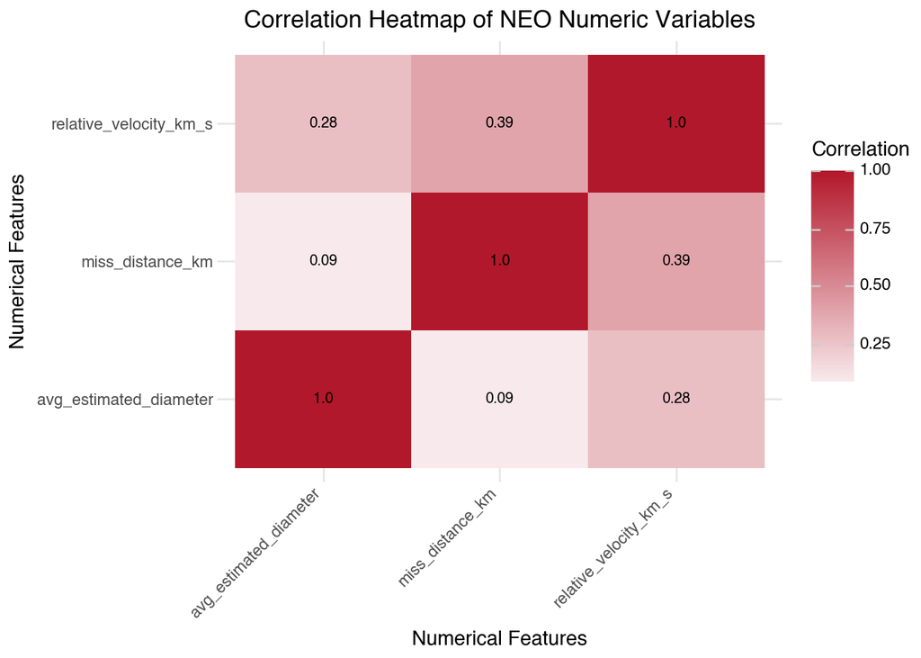

```python
heatmap_vars = [
    "avg_estimated_diameter",
    "miss_distance_km",
    "relative_velocity_km_s",
]

corr_matrix = neo_df_derived[heatmap_vars].corr()

corr_long = (
    corr_matrix
    .reset_index()
    .melt(id_vars="index", var_name="variable_2", value_name="correlation")
    .rename(columns={"index": "variable_1"})
)
corr_long["corr_label"] = corr_long["correlation"].round(2)

(
    ggplot(corr_long, aes(x="variable_1", y="variable_2", fill="correlation"))
    + geom_tile()
    + geom_text(aes(label="corr_label"), size=8, color="black")
    + scale_fill_gradient2(low="#2166ac", mid="white", high="#b2182b", midpoint=0)
    + labs(
        title="Correlation Heatmap of NEO Numeric Variables",
        x="Numerical Features",
        y="Numerical Features",
        fill="Correlation"
    )
    + theme_minimal()
    + theme(axis_text_x=element_text(angle=45, ha="right"))
)
```

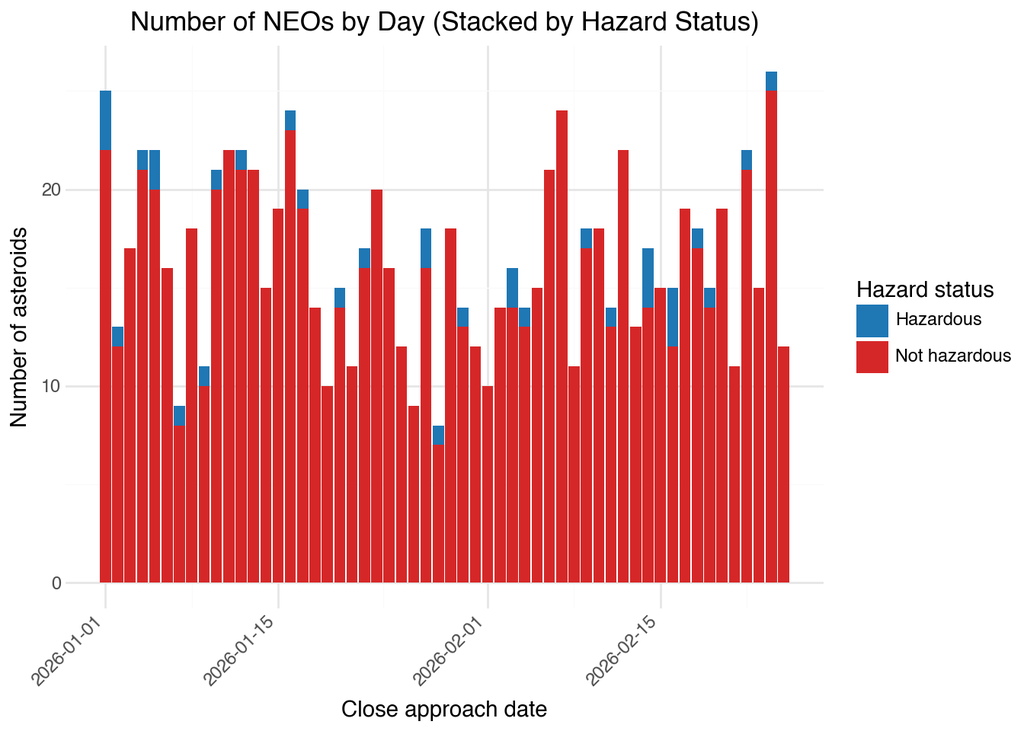

```python
plot_df = neo_df_derived.copy()
plot_df["close_approach_date"] = pd.to_datetime(plot_df["close_approach_date"])
plot_df["hazard_status"] = np.where(
    plot_df["is_potentially_hazardous"] == 1,
    "Hazardous",
    "Not hazardous"
)

(
    ggplot(plot_df, aes(x="close_approach_date", fill="hazard_status"))
    + geom_bar(position="stack")
    + labs(
        title="Number of NEOs by Day (Stacked by Hazard Status)",
        x="Close approach date",
        y="Number of asteroids",
        fill="Hazard status"
    )
    + scale_fill_manual(values=["#1f77b4", "#d62728"])
    + theme_minimal()
    + theme(axis_text_x=element_text(angle=45, ha="right"))
)
```

## 3. (6 points)

Are larger NEOs more hazardous? Are faster NEOs more hazardous? Create two histograms to explore these questions, and conduct two-sample t-tests. Is the relationship between diameter and velocity different between hazardous and non-hazardous NEOs? Create a scatterplot to explore this. Summarize your results.

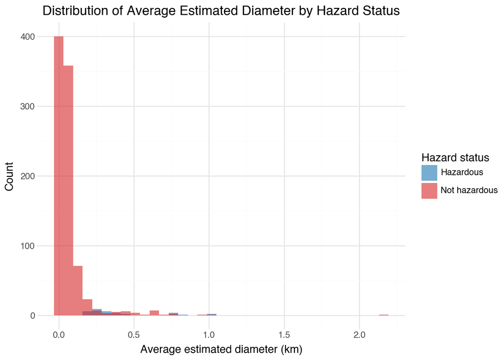

```python
q3_df = neo_df_derived.copy()
q3_df["hazard_status"] = np.where(
    q3_df["is_potentially_hazardous"] == 1,
    "Hazardous",
    "Not hazardous"
)

(
    ggplot(
        q3_df,
        aes(x="avg_estimated_diameter", fill="hazard_status")
    )
    + geom_histogram(position="identity", alpha=0.6, bins=35)
    + labs(
        title="Distribution of Average Estimated Diameter by Hazard Status",
        x="Average estimated diameter (km)",
        y="Count",
        fill="Hazard status"
    )
    + scale_fill_manual(values=["#1f77b4", "#d62728"])
    + theme_minimal()
)
```

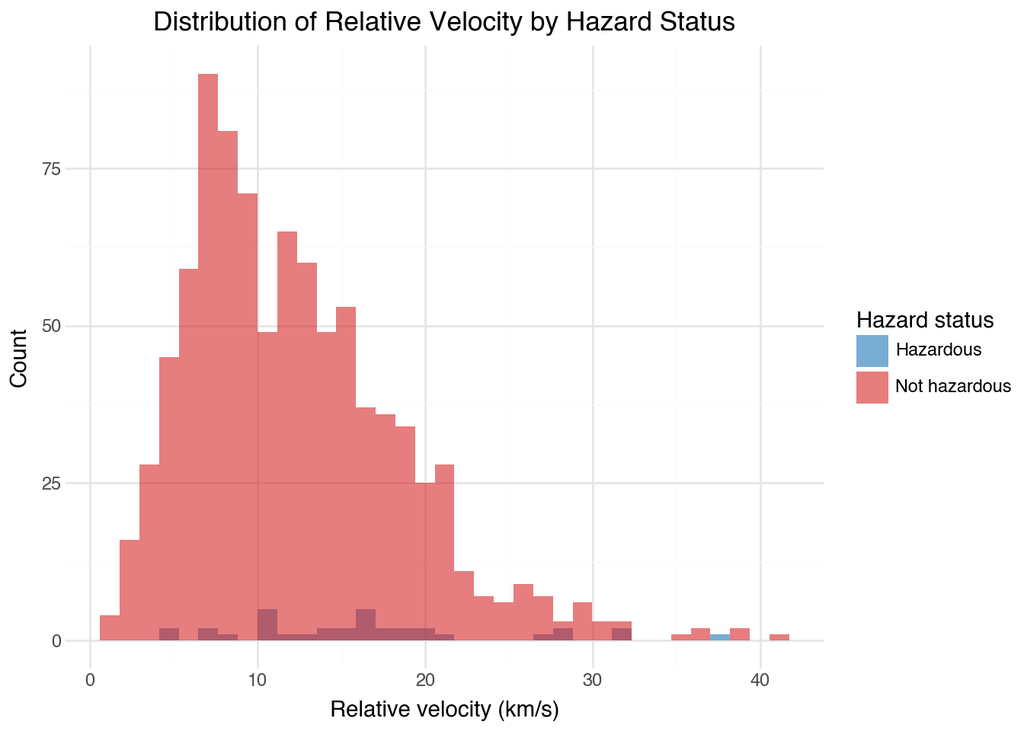

```python
(
    ggplot(
        q3_df,
        aes(x="relative_velocity_km_s", fill="hazard_status")
    )
    + geom_histogram(position="identity", alpha=0.6, bins=35)
    + labs(
        title="Distribution of Relative Velocity by Hazard Status",
        x="Relative velocity (km/s)",
        y="Count",
        fill="Hazard status"
    )
    + scale_fill_manual(values=["#1f77b4", "#d62728"])
    + theme_minimal()
)
```

```python
# 1. Split data into hazardous and non-hazardous groups
haz = neo_df_derived[neo_df_derived["is_potentially_hazardous"] == 1]
non_haz = neo_df_derived[neo_df_derived["is_potentially_hazardous"] == 0]

# 2. Run two-sample t-test for average estimated diameter (Welch's t-test)
diam_haz = haz["avg_estimated_diameter"]
diam_non_haz = non_haz["avg_estimated_diameter"]
ttest_diameter = stats.ttest_ind(diam_haz, diam_non_haz, equal_var=False)

# 3. Run two-sample t-test for relative velocity (Welch's t-test)
vel_haz = haz["relative_velocity_km_s"]
vel_non_haz = non_haz["relative_velocity_km_s"]
ttest_velocity = stats.ttest_ind(vel_haz, vel_non_haz, equal_var=False)

# 4. Summarize test outputs in one table
ttest_results = pd.DataFrame({
    "variable": ["avg_estimated_diameter", "relative_velocity_km_s"],
    "mean_hazardous": [diam_haz.mean(), vel_haz.mean()],
    "mean_non_hazardous": [diam_non_haz.mean(), vel_non_haz.mean()],
    "n_hazardous": [len(diam_haz), len(vel_haz)],
    "n_non_hazardous": [len(diam_non_haz), len(vel_non_haz)],
    "t_statistic": [ttest_diameter.statistic, ttest_velocity.statistic],
    "p_value": [ttest_diameter.pvalue, ttest_velocity.pvalue],
})
ttest_results["significant_0.05"] = ttest_results["p_value"] < 0.05

display(ttest_results.round(6))
```

|  | variable | mean_hazardous | mean_non_hazardous | n_hazardous | n_non_hazardous | t_statistic | p_value | significant_0.05 |
| --- | --- | --- | --- | --- | --- | --- | --- | --- |
| 0 | avg_estimated_diameter | 0.399706 | 0.067277 | 34 | 891 | 7.924175 | 0.000000 | True |
| 1 | relative_velocity_km_s | 16.761754 | 12.189980 | 34 | 891 | 3.316784 | 0.002147 | True |

**Summary:**

- According to the Distribution of Average Estimated Diameter by Hazard Status histogram, visually larger NEOs look more hazardous. The two-sample t-test confirms this statistically because the mean of the average estimated diameter for hazardous NEOs is significantly larger than the mean of the average estimated diameter for non-hazardous NEOs with p-value < 0.05.
- While the relative velocity distributions do not appear vastly different visually, the two-sample t-test confirms this statistically because the mean of the relative velocity for hazardous NEOs is significantly larger than the mean of the relative velocity for non-hazardous NEOs with p-value < 0.05.

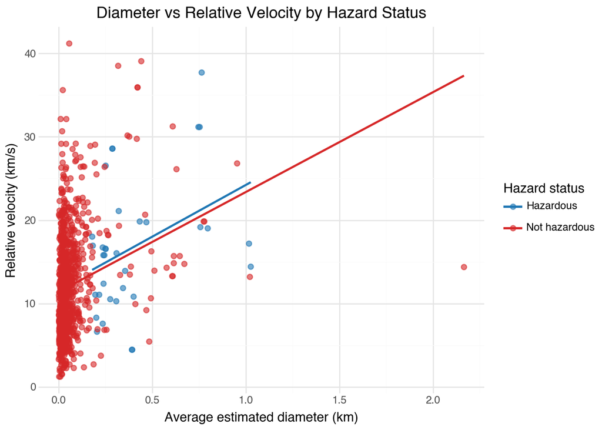

```python
scatter_df = neo_df_derived.copy()
scatter_df["hazard_status"] = np.where(
    scatter_df["is_potentially_hazardous"] == 1,
    "Hazardous",
    "Not hazardous"
)

(
    ggplot(
        scatter_df,
        aes(x="avg_estimated_diameter", y="relative_velocity_km_s", color="hazard_status")
    )
    + geom_point(alpha=0.6, size=2)
    + geom_smooth(method="lm", se=False)
    + labs(
        title="Diameter vs Relative Velocity by Hazard Status",
        x="Average estimated diameter (km)",
        y="Relative velocity (km/s)",
        color="Hazard status"
    )
    + scale_color_manual(values=["#1f77b4", "#d62728"])
    + theme_minimal()
)
```

**Summary:**

- According to the Diameter vs Relative Velocity by Hazard Status scatterplot, the relationship between diameter and velocity does not appear substantially different between hazardous and non-hazardous NEOs. The trend lines for both groups show a positive correlation, indicating that as diameter increases, relative velocity tends to increase for all NEOs.

## 4. (5 points)

Split the data into 70% train and 30% test, and fit a logistic regression model on train to see if we can predict on test whether an asteroid is hazardous based on its attributes (include diameter, velocity, miss distance). Summarize and interpret the results (include a confusion matrix, accuracy, precision, recall, and F1; plot the ROC curve).

```
Training set size: 647
Testing set size: 278

Training target proportions:
is_potentially_hazardous
0    0.962906
1    0.037094
Name: proportion, dtype: float64
Test Accuracy: 0.9640
Test Precision: 0.0000
Test Recall: 0.0000
Test F1: 0.0000
Test ROC AUC: 0.2810
```

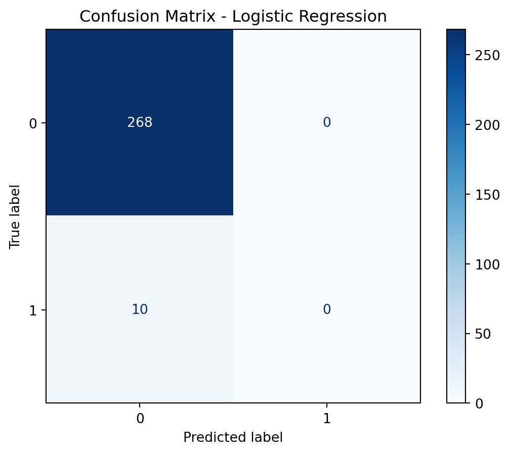

```python
# 1. Set up predictors and target
feature_cols = ["avg_estimated_diameter", "relative_velocity_km_s", "miss_distance_km"]
X_class = neo_df_derived[feature_cols]
y_class = neo_df_derived["is_potentially_hazardous"]

# 2. Train/test split (70/30) with random_state=65
X_train_c, X_test_c, y_train_c, y_test_c = train_test_split(
    X_class, y_class, test_size=0.30, random_state=65, stratify=y_class
)

print(f"Training set size: {X_train_c.shape[0]}")
print(f"Testing set size: {X_test_c.shape[0]}")
print("\nTraining target proportions:")
print(y_train_c.value_counts(normalize=True).sort_index())

# 3. Fit logistic regression
log_reg_c = LogisticRegression(max_iter=1000)
log_reg_c.fit(X_train_c, y_train_c)

# 4. Predict on test set
y_pred_c = log_reg_c.predict(X_test_c)
y_prob_c = log_reg_c.predict_proba(X_test_c)[:, 1]

# 5. Test metrics + confusion matrix display
test_acc_c = accuracy_score(y_test_c, y_pred_c)
test_precision_c = precision_score(y_test_c, y_pred_c, zero_division=0)
test_recall_c = recall_score(y_test_c, y_pred_c, zero_division=0)
test_f1_c = f1_score(y_test_c, y_pred_c, zero_division=0)
test_auc_c = roc_auc_score(y_test_c, y_prob_c)

print(f"Test Accuracy: {test_acc_c:.4f}")
print(f"Test Precision: {test_precision_c:.4f}")
print(f"Test Recall: {test_recall_c:.4f}")
print(f"Test F1: {test_f1_c:.4f}")
print(f"Test ROC AUC: {test_auc_c:.4f}")

class_labels = [0, 1]
cm = confusion_matrix(y_test_c, y_pred_c, labels=class_labels)
disp = ConfusionMatrixDisplay(confusion_matrix=cm, display_labels=class_labels)
disp.plot(cmap="Blues")
plt.title("Confusion Matrix - Logistic Regression")
plt.show()
```

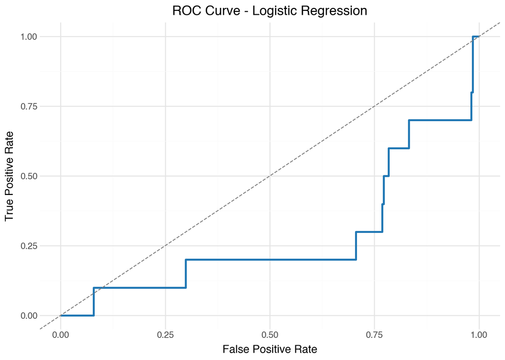

```python
fpr, tpr, _ = roc_curve(y_test_c, y_prob_c)
roc_df = pd.DataFrame({"fpr": fpr, "tpr": tpr})

(
    ggplot(roc_df, aes(x="fpr", y="tpr"))
    + geom_line(color="#1f77b4", size=1.1)
    + geom_abline(intercept=0, slope=1, linetype="dashed", color="gray")
    + labs(
        title="ROC Curve - Logistic Regression",
        x="False Positive Rate",
        y="True Positive Rate"
    )
    + theme_minimal()
)
```

**Summary:**

- **Class Imbalance**: The training set is highly imbalanced, with hazardous NEOs representing only approximately 3.71% of the data. A naive model predicting “non-hazardous” for every instance would achieve approximately 96.29% accuracy by default.
- **Confusion Matrix**: The logistic regression model correctly identified all 268 non-hazardous NEOs (True Negatives) but missed all 10 hazardous NEOs (False Negatives), resulting in 0 True Positives. This proves that the model performed as expected and failed to detect hazardous NEOs.
- **Metrics Interpretation**: The high **accuracy** (96.4%) is misleading due to the imbalance and naiveness. The **precision** (0.0), **recall** (0.0), and **F1** (0.0) scores accurately reflect that the model failed completely at its primary task: detecting hazardous asteroids.
- **ROC AUC**: The ROC AUC of 0.281 is below 0.5, meaning the model performs **worse** than random guessing. The ROC curve falls below the diagonal dashed line, indicating that the model’s predicted probabilities are inversely calibrated — it tends to assign *lower* scores to truly hazardous asteroids than to non-hazardous ones. At the default threshold, the True Positive Rate is 0, meaning no hazardous asteroids are caught.

## 5. (5 points)

Repeat 4 but using random forest. Summarize and include a comparison of your results in 4.

```
RF Test Accuracy: 0.9712
RF Test Precision: 0.6667
RF Test Recall: 0.4000
RF Test F1: 0.5000
RF Test ROC AUC: 0.9877
```

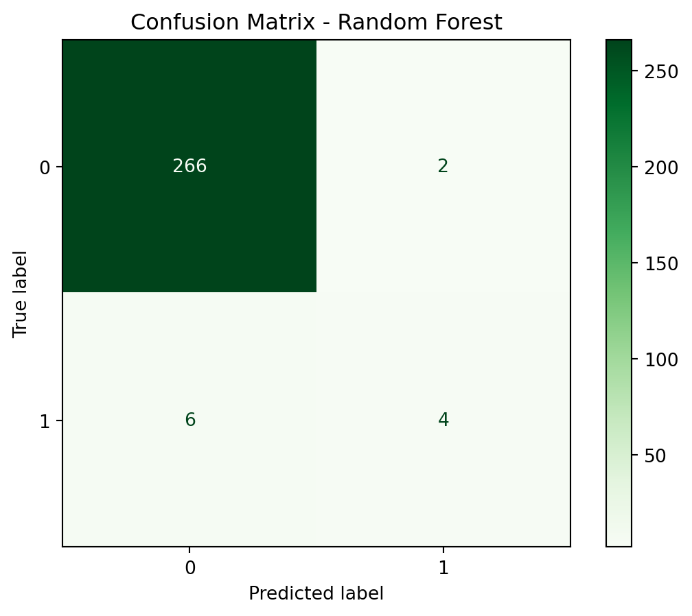

```python
# 1. Fit random forest on the same train/test split used in Q4
rf_class = RandomForestClassifier(
    n_estimators=500,
    random_state=65
)
rf_class.fit(X_train_c, y_train_c)

# 2. Predict on test set
y_pred_rf_c = rf_class.predict(X_test_c)
y_prob_rf_c = rf_class.predict_proba(X_test_c)[:, 1]

# 3. Evaluate random forest performance
rf_test_acc_c = accuracy_score(y_test_c, y_pred_rf_c)
rf_test_precision_c = precision_score(y_test_c, y_pred_rf_c, zero_division=0)
rf_test_recall_c = recall_score(y_test_c, y_pred_rf_c, zero_division=0)
rf_test_f1_c = f1_score(y_test_c, y_pred_rf_c, zero_division=0)
rf_test_auc_c = roc_auc_score(y_test_c, y_prob_rf_c)

print(f"RF Test Accuracy: {rf_test_acc_c:.4f}")
print(f"RF Test Precision: {rf_test_precision_c:.4f}")
print(f"RF Test Recall: {rf_test_recall_c:.4f}")
print(f"RF Test F1: {rf_test_f1_c:.4f}")
print(f"RF Test ROC AUC: {rf_test_auc_c:.4f}")

class_labels = [0, 1]
rf_cm = confusion_matrix(y_test_c, y_pred_rf_c, labels=class_labels)
rf_disp = ConfusionMatrixDisplay(confusion_matrix=rf_cm, display_labels=class_labels)
rf_disp.plot(cmap="Greens")
plt.title("Confusion Matrix - Random Forest")
plt.show()
```

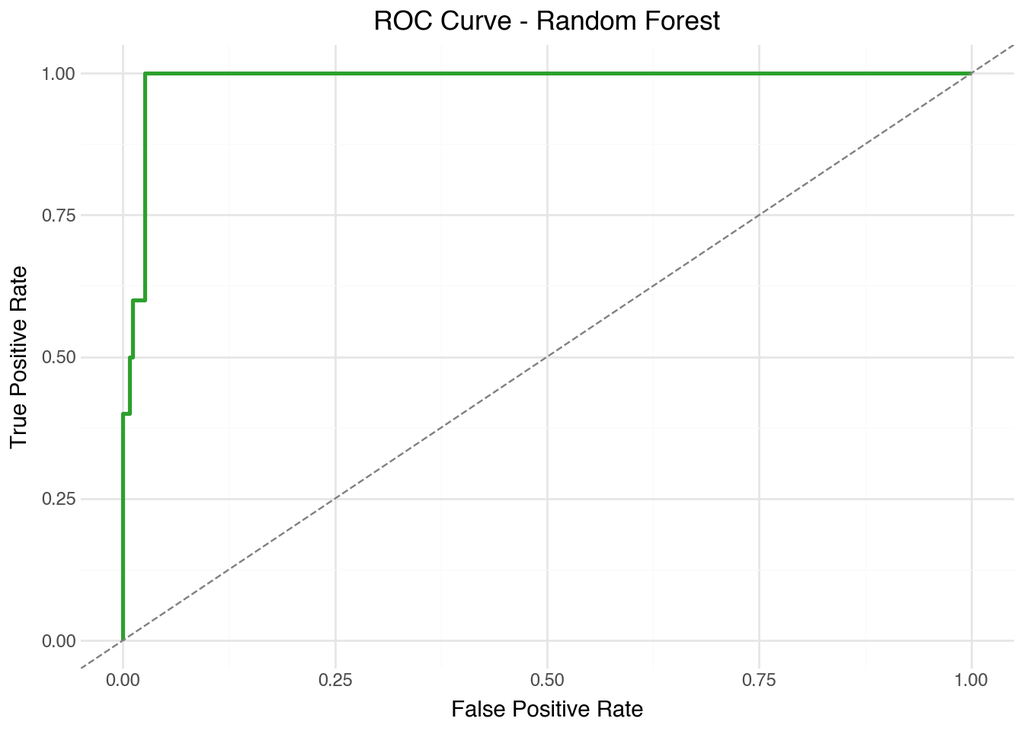

```python
rf_fpr, rf_tpr, _ = roc_curve(y_test_c, y_prob_rf_c)
rf_roc_df = pd.DataFrame({"fpr": rf_fpr, "tpr": rf_tpr})

(
    ggplot(rf_roc_df, aes(x="fpr", y="tpr"))
    + geom_line(color="#2ca02c", size=1.1)
    + geom_abline(intercept=0, slope=1, linetype="dashed", color="gray")
    + labs(
        title="ROC Curve - Random Forest",
        x="False Positive Rate",
        y="True Positive Rate"
    )
    + theme_minimal()
)
```

```python
comparison_df = pd.DataFrame({
    "model": ["Logistic Regression", "Random Forest"],
    "accuracy": [test_acc_c, rf_test_acc_c],
    "precision": [test_precision_c, rf_test_precision_c],
    "recall": [test_recall_c, rf_test_recall_c],
    "f1": [test_f1_c, rf_test_f1_c],
    "roc_auc": [test_auc_c, rf_test_auc_c],
})

display(comparison_df.round(4))
```

|  | model | accuracy | precision | recall | f1 | roc_auc |
| --- | --- | --- | --- | --- | --- | --- |
| 0 | Logistic Regression | 0.9640 | 0.0000 | 0.0 | 0.0 | 0.2810 |
| 1 | Random Forest | 0.9712 | 0.6667 | 0.4 | 0.5 | 0.9877 |

**Summary:**

- **Confusion Matrix:** Out of the 10 actual hazardous NEOs in the test set, the Random Forest model correctly identified 4 (True Positives) but missed 6 (False Negatives). It correctly identified 266 non-hazardous NEOs (True Negatives) while incorrectly labeling 2 non-hazardous NEO as hazardous (False Positives).
- **Metrics Interpretation:** The model achieved an accuracy of 97.12%, a precision of 0.6667, a recall of 0.4, and an F1 score of 0.5. Because 67.0% of the asteroids it flagged as hazardous were actually hazardous, it demonstrates good reliability in its positive predictions, though the recall (40.0%) means it is still missing more than half of the dangerous asteroids.
- **ROC Curve:** The ROC curve rises sharply toward the top-left corner, yielding an exceptionally high ROC AUC of 0.9877. This indicates the model has an excellent underlying ability to separate hazardous from non-hazardous NEOs based on their predicted probabilities.
- **Comparison with Logistic Regression:** The Random Forest model performed significantly better than the Logistic Regression model. While Logistic Regression failed to identify any hazardous NEOs (Precision=0.0, Recall=0.0), the Random Forest model successfully identified 4 hazardous NEOs with a precision of 0.6667 and a recall of 0.4. The Random Forest’s ROC AUC of 0.9877 is also much higher than the Logistic Regression’s (0.281), confirming its superior predictive power for this imbalanced dataset.

# CFPB API (Part 2)

The Consumer Financial Protection Bureau maintains a database of customer complaints. We will use natural language processing to see if there are any trends in the reported consumer’s narrative description of the complaints. The data can be acquired here. We will use the API to get data.

## 6. (3 points)

Use the API to get consumer complaint narratives (i.e. has_narrative) from the last 3 months (i.e. date_received_min is November 1, 2025) across all product categories. I suggest using the csv format. Please note this is a very large dataset so may take some time to query (you can use a longer timeout). Once you have pulled the data, summarize the dimensions and variables. Create a bar chart of complaint counts by product category.

```python
# CFPB Consumer Complaint Database API endpoint
CFPB_BASE_URL = "https://www.consumerfinance.gov/data-research/consumer-complaints/search/api/v1/"

# Pull complaints with narratives from the last 3 months (from 2025-11-01)
cfpb_params = {
    "format": "csv",
    "date_received_min": "2025-11-01",
    "has_narrative": "true",
    "no_aggs": "true",
    "field": "all",
    "sort": "created_date_desc",
    "size": 250000,
}

# Make the GET request
cfpb_response = requests.get(CFPB_BASE_URL, params=cfpb_params, timeout=120)
print(f"Status Code: {cfpb_response.status_code}")
print(f"Request URL: {cfpb_response.url}")
cfpb_response.raise_for_status()

# 3. Read CSV payload into DataFrame
cfpb_df = pd.read_csv(StringIO(cfpb_response.text))

cfpb_df.head()
```

```
Status Code: 200
Request URL: https://www.consumerfinance.gov/data-research/consumer-complaints/search/api/v1/?format=csv&date_received_min=2025-11-01&has_narrative=true&no_aggs=true&field=all&sort=created_date_desc&size=250000
```

|  | Date received | Product | Sub-product | Issue | Sub-issue | Consumer complaint narrative | Company public response | Company | State | ZIP code | Tags | Consumer consent provided? | Submitted via | Date sent to company | Company response to consumer | Timely response? | Consumer disputed? | Complaint ID |
| --- | --- | --- | --- | --- | --- | --- | --- | --- | --- | --- | --- | --- | --- | --- | --- | --- | --- | --- |
| 0 | 12/22/25 | Student loan | Private student loan | Issue where my lender is my school | Issues with fees connected to the loan | My spouse and I attended XXXX XXXX XXXX from X... | NaN | Maximus Federal Services, Inc. | TX | 75243 | NaN | Consent provided | Web | 12/22/25 | Closed with explanation | Yes | NaN | 18232083 |
| 1 | 12/04/25 | Credit reporting or other personal consumer re... | Credit reporting | Improper use of your report | Reporting company used your report improperly | You have reported inaccurate and unauthorized ... | NaN | EQUIFAX, INC. | SC | 292XX | NaN | Consent provided | Web | 12/04/25 | Closed with explanation | Yes | NaN | 17704511 |
| 2 | 11/10/25 | Credit reporting or other personal consumer re... | Credit reporting | Problem with a company's investigation into an... | Their investigation did not fix an error on yo... | I'm really not sure what happened. I have mail... | Company has responded to the consumer and the ... | Experian Information Solutions Inc. | OH | 444XX | NaN | Consent provided | Web | 11/10/25 | Closed with explanation | Yes | NaN | 17149551 |
| 3 | 12/23/25 | Credit reporting or other personal consumer re... | Credit reporting | Incorrect information on your report | Account information incorrect | To Whom It May Concern, I am writing to formal... | Company believes it acted appropriately as aut... | NAVY FEDERAL CREDIT UNION | NC | 28311 | NaN | Consent provided | Web | 12/23/25 | Closed with non-monetary relief | Yes | NaN | 18239740 |
| 4 | 11/13/25 | Credit reporting or other personal consumer re... | Credit reporting | Incorrect information on your report | Information belongs to someone else | I am disputing the following inquiries on my E... | NaN | EQUIFAX, INC. | NC | 27215 | NaN | Consent provided | Web | 11/13/25 | Closed with non-monetary relief | Yes | NaN | 17234963 |

```python
print(f"CFPB dataset dimensions: {cfpb_df.shape}")
print(f"Number of variables: {len(cfpb_df.columns)}")
print(cfpb_df.info())
```

```
CFPB dataset dimensions: (155183, 18)
Number of variables: 18
<class 'pandas.core.frame.DataFrame'>
RangeIndex: 155183 entries, 0 to 155182
Data columns (total 18 columns):
 #   Column                        Non-Null Count   Dtype
---  ------                        --------------   -----
 0   Date received                 155183 non-null  object
 1   Product                       155183 non-null  object
 2   Sub-product                   155183 non-null  object
 3   Issue                         155183 non-null  object
 4   Sub-issue                     147720 non-null  object
 5   Consumer complaint narrative  155183 non-null  object
 6   Company public response       81229 non-null   object
 7   Company                       155183 non-null  object
 8   State                         154672 non-null  object
 9   ZIP code                      155183 non-null  object
 10  Tags                          11444 non-null   object
 11  Consumer consent provided?    155183 non-null  object
 12  Submitted via                 155183 non-null  object
 13  Date sent to company          155183 non-null  object
 14  Company response to consumer  155183 non-null  object
 15  Timely response?              155183 non-null  object
 16  Consumer disputed?            0 non-null       float64
 17  Complaint ID                  155183 non-null  int64
dtypes: float64(1), int64(1), object(16)
memory usage: 21.3+ MB
None
```

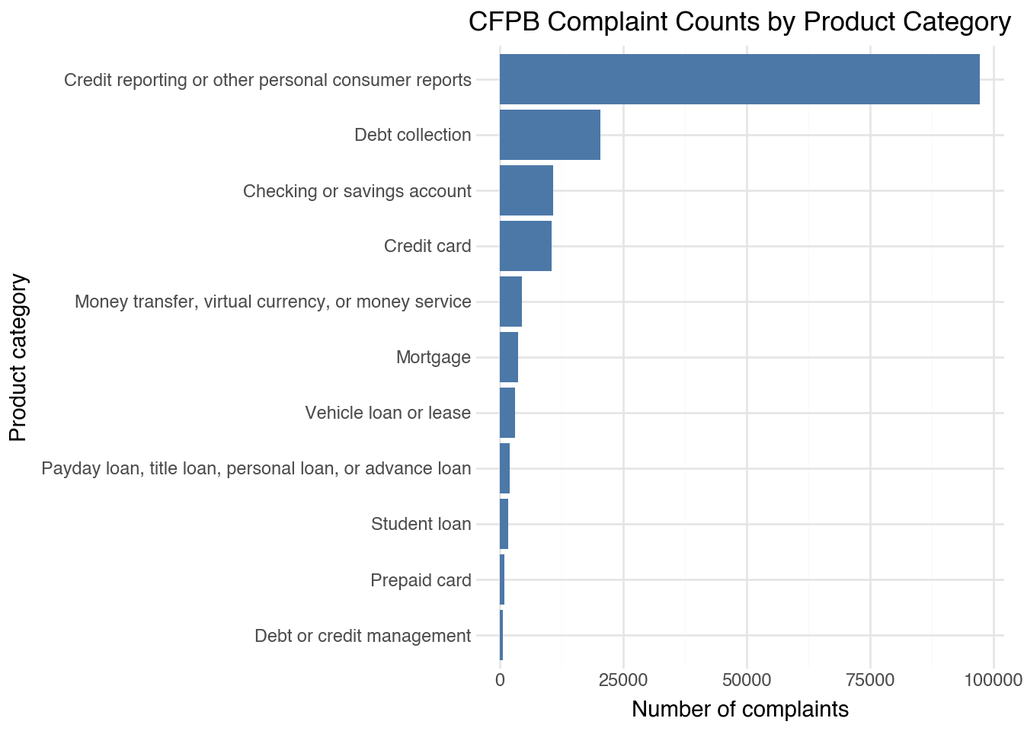

```python
product_counts = (
    cfpb_df["Product"]
    .value_counts()
    .reset_index()
)
product_counts.columns = ["Product", "Count"]

(
    ggplot(product_counts, aes(x="reorder(Product, Count)", y="Count"))
    + geom_col(fill="#4C78A8")
    + coord_flip()
    + labs(
        title="CFPB Complaint Counts by Product Category",
        x="Product category",
        y="Number of complaints"
    )
    + theme_minimal()
)
```

**Summary:**

- The dataset contains 155183 customer complaint narratives since November 1, 2025 with 18 features each.
- According to CFPB Complaint Counts by Product Category Since November 1, 2025 bar chart, the most frequent product category with complaints is “Credit reporting or other personal consumer reports”. Note, this product category have way more complaints than all the other product categories.

## 7. (2 points)

Tokenize the complaints (consumer complaint narrative) and count the number of tokens. Make a plot of the top 20 tokens. Summarize.

```
Total number of tokens: 32157207
```

|  | word | count |
| --- | --- | --- |
| 0 | xxxx | 1946586 |
| 1 | . | 1260811 |
| 2 | , | 1144745 |
| 3 | the | 1085714 |
| 4 | and | 830412 |
| 5 | to | 756822 |
| 6 | i | 682281 |
| 7 | of | 563751 |
| 8 | a | 536032 |
| 9 | my | 511992 |
| 10 | ) | 377731 |
| 11 | ( | 374009 |
| 12 | credit | 337048 |
| 13 | : | 326254 |
| 14 | this | 325665 |
| 15 | that | 316161 |
| 16 | account | 272484 |
| 17 | is | 263446 |
| 18 | not | 256210 |
| 19 | on | 223581 |

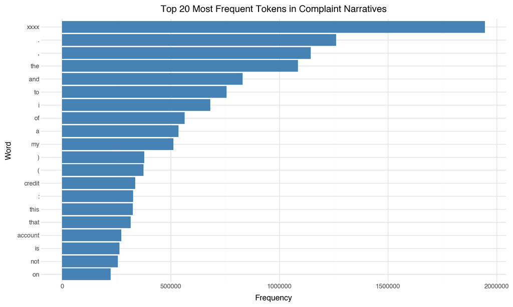

```python
# Tokenize all complaint narratives
def tokenize_text(text):
    if pd.isna(text):
        return []
    return word_tokenize(text.lower())

all_tokens = []
for text in cfpb_df["Consumer complaint narrative"]:
    all_tokens.extend(tokenize_text(text))

# Count total tokens
total_tokens = len(all_tokens)
print(f"Total number of tokens: {total_tokens}")

# Count token frequencies and get top 20
token_counts = Counter(all_tokens)
top_20_tokens = token_counts.most_common(20)
top_20_tokens_df = pd.DataFrame(top_20_tokens, columns=["word", "count"])
display(top_20_tokens_df)

# Plot top 20 tokens
(
    ggplot(top_20_tokens_df, aes(x="reorder(word, count)", y="count"))
    + geom_bar(stat="identity", fill="steelblue")
    + coord_flip()
    + labs(
        title="Top 20 Most Frequent Tokens in Complaint Narratives",
        x="Word",
        y="Frequency"
    )
    + theme_minimal()
    + theme(figure_size=(10, 6))
)
```

**Summary:**

- There are 32157207 tokens in total in the customer complaint narratives since November 1, 2025.
- It is very obvious that punctuations, stopwords, and privacy mask words like “XXXX” are the most frequent words in the data. Without removing them, we cannot discover any meaningful themes and trends in the customer complaint narratives.

## 8. (3 points)

Remove stopwords, including numeric tokens, special characters combinations, and customize to remove any other words that look strange. After cleaning, what words appear as the most frequent? Create a plot of the 20 most common complaint tokens in your cleaned data and summarize.

```
Number of cleaned tokens: 13697663
```

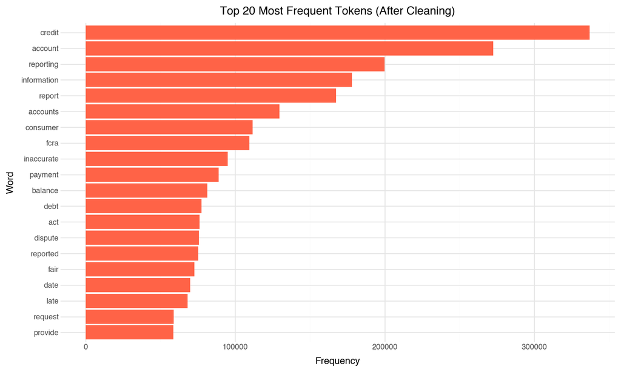

```python
# Get English stopwords
stop_words = set(stopwords.words("english"))

# Add custom stopwords
custom_stopwords = {"xxxx", "xxx", "xx", "x"}

# Combine stopwords
stop_words = stop_words.union(custom_stopwords)

# Filter tokens
cleaned_tokens = [
    token for token in all_tokens
    if token not in stop_words
    and not token.isdigit()
    and len(token) > 2
    and token.isalpha()
]

# Count cleaned tokens
print(f"Number of cleaned tokens: {len(cleaned_tokens)}")

# Count cleaned tokens frequencies and get top 20
cleaned_counts = Counter(cleaned_tokens)
top_20_cleaned = cleaned_counts.most_common(20)
top_20_cleaned_df = pd.DataFrame(top_20_cleaned, columns=["word", "count"])

# Plot top 20 cleaned tokens
(
    ggplot(top_20_cleaned_df, aes(x="reorder(word, count)", y="count"))
    + geom_bar(stat="identity", fill="tomato")
    + coord_flip()
    + labs(
        title="Top 20 Most Frequent Tokens (After Cleaning)",
        x="Word",
        y="Frequency"
    )
    + theme_minimal()
    + theme(figure_size=(10, 6))
)
```

**Summary:**

- After removing english stopwords, punctuations, and custom noise tokens (e.g., “xxxx”), the most frequent words are “credit”, “account”, and “reporting”.
- This aligns with the earlier finding that “Credit reporting or other personal consumer reports” is the dominant product category in the customer complaint narratives dataset. The top words clearly reflect themes of credit reporting disputes, account information inaccuracy, and consumer identity issues, and more.
- The cleaned token list is much more informative than the raw list and more meaningful in terms of complaints.

## 9. (10 points)

Use Latent Dirichlet Allocation (LDA) topic modeling to discover topics in the complaint narratives. First, use perplexity and log-likelihood on a held-out sample of 50,000 to evaluate different numbers of topics (e.g., 2 to 10) and select an appropriate number. Plot perplexity and log-likelihood as a function of the number of topics. Then fit an LDA model with your chosen number of topics. Display the top 10 words for each topic. Do the discovered topics align with the actual product categories? Create a visualization to compare. Summarize and interpret your findings.

```python
# Prepare text and product data
lda_df = cfpb_df[["Consumer complaint narrative", "Product"]].dropna(
    subset=["Consumer complaint narrative", "Product"]
).copy()
lda_df["Consumer complaint narrative"] = lda_df["Consumer complaint narrative"].astype(str)

print(f"Total documents available for LDA: {lda_df.shape[0]}")

# Create held-out sample of 50,000
heldout_n = 50000
if lda_df.shape[0] <= heldout_n:
    raise ValueError("Not enough rows to create a held-out sample of 50,000.")

train_df, holdout_df = train_test_split(
    lda_df,
    test_size=heldout_n,
    random_state=65
)

print(f"Training documents: {train_df.shape[0]}")
print(f"Held-out documents: {holdout_df.shape[0]}")

# Build document-term matrices
lda_stop_words = set(stopwords.words("english")).union({"xxxx", "xxx", "xx", "x"})

vectorizer_eval = CountVectorizer(
    stop_words=list(lda_stop_words),
    token_pattern=r"(?u)\b[a-zA-Z]{3,}\b",
    max_df=0.95,
    min_df=5,
    max_features=5000
)

X_train_eval = vectorizer_eval.fit_transform(train_df["Consumer complaint narrative"])
X_holdout_eval = vectorizer_eval.transform(holdout_df["Consumer complaint narrative"])

# Evaluate k = 2..10 using held-out perplexity and log-likelihood
k_values = list(range(2, 11))
lda_eval_rows = []

for k in k_values:
    lda_k = LatentDirichletAllocation(
        n_components=k,
        random_state=65,
        max_iter=10,
        learning_method="batch"
    )
    lda_k.fit(X_train_eval)

    lda_eval_rows.append({
        "n_topics": k,
        "perplexity": lda_k.perplexity(X_holdout_eval),
        "log_likelihood": lda_k.score(X_holdout_eval)
    })

lda_eval_df = pd.DataFrame(lda_eval_rows)
display(lda_eval_df)
```

```
Total documents available for LDA: 155183
Training documents: 105183
Held-out documents: 50000
```

|  | n_topics | perplexity | log_likelihood |
| --- | --- | --- | --- |
| 0 | 2 | 838.862143 | -2.979470e+07 |
| 1 | 3 | 822.180006 | -2.970580e+07 |
| 2 | 4 | 775.494107 | -2.944707e+07 |
| 3 | 5 | 728.923524 | -2.917297e+07 |
| 4 | 6 | 698.842299 | -2.898645e+07 |
| 5 | 7 | 674.783447 | -2.883140e+07 |
| 6 | 8 | 658.938412 | -2.872624e+07 |
| 7 | 9 | 650.320847 | -2.866797e+07 |
| 8 | 10 | 635.137068 | -2.856342e+07 |

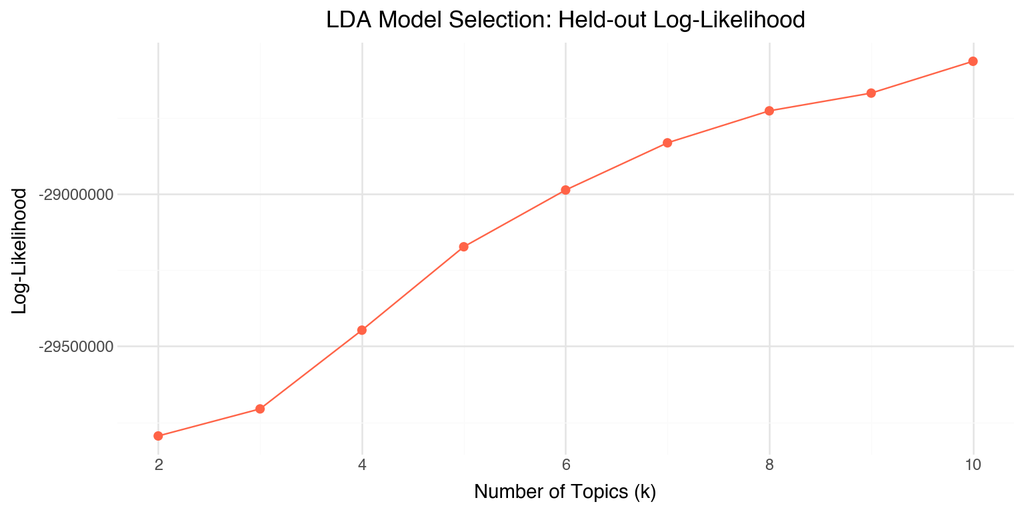

```python
(
    ggplot(lda_eval_df, aes(x="n_topics", y="perplexity"))
    + geom_line(color="steelblue")
    + geom_point(color="steelblue", size=2)
    + labs(
        title="LDA Model Selection: Held-out Perplexity",
        x="Number of Topics (k)",
        y="Perplexity"
    )
    + theme_minimal()
    + theme(figure_size=(8, 4))
)

(
    ggplot(lda_eval_df, aes(x="n_topics", y="log_likelihood"))
    + geom_line(color="tomato")
    + geom_point(color="tomato", size=2)
    + labs(
        title="LDA Model Selection: Held-out Log-Likelihood",
        x="Number of Topics (k)",
        y="Log-Likelihood"
    )
    + theme_minimal()
    + theme(figure_size=(8, 4))
)
```

[output not shown]

```python
# Choose k using minimum held-out perplexity
best_k = int(lda_eval_df.loc[lda_eval_df["perplexity"].idxmin(), "n_topics"])
print(f"Chosen number of topics (based on minimum held-out perplexity): {best_k}")
```

```
Chosen number of topics (based on minimum held-out perplexity): 10
```